# Senior Thesis

Andrew Cooper

April 2018

# Abstract

This research project focuses on modeling social networks with count relationships. In count networks, relationships have associated magnitudes or frequencies. For instance, in friendship communication networks, the relationship between two actors can be the number of times one friend communicates with another. This project assesses how does capturing the magnitudes of relationships in social networks improves model accuracy. In other words, if relationships are treated as binary instead, how much worse do models perform in comparison? In addition, we explore count networks in restricted or censored cases, where not all ties in the network are observed. We examine how censored information in a count network can impede on model accuracy. We also develop a likelihood that takes into account the censored nature of a network and assess its performance in inferring unobserved ties. We conduct a simulation study comparing these methods; we then apply these methods to friendship networks from the Add Health study. In the simulation study, the binary model performs significantly and consistently poorly in estimating network parameters, indicating that the magnitudes of network ties provide important predictive information. In addition, the designed likelihood for censored networks significantly improve model performance.

# Introduction

Social network analysis often has the goal of inferring underlying relationships between actors given the observance of some dyadic metric. For instance, one can use the frequency of Email correspondence between actors to infer the existence of relationships.

In many cases, an actor’s relationships with other actors in the network can be determined based on a variety of actor-specific and partner-specific attributes. For instance, in a friendship network, the friendship between two students in a school could be determined by their relative ages, their school grades, or other demographic characteristics. These attributes can be indicators of an actor’s behavior in a network, including that actor’s “sender” behavior (who he or she chooses to befriend) and “receiver” behavior (who he or she is befriend by). Research by Hoff and Volfovsky has explored the use of regressive models to predict network relationships. These models include “additive” and “multiplicative” effects.

Depending on the network, the dyadic metric connecting actors to each other could be binary or weighted. Relationships could simply exist or not exist (e.g. two actors are either “friends” or “not friends”), or could have some kind of scale or magnitude attributed to them, (e.g. two people could have some number of Emails sent between them). In some cases, the ties are ranked in such a way that some ties are more “significant” than other ties, such as in the Add Health dataset, where participants were asked to rank their top five friends. One question of interest is how much information the magnitudes of ties in count networks provide. In other words, if we censor the network such that ties are only treated as binary, how much does our model suffer in terms of accuracy in capturing network features?

Another feature of some networks is the knowledge that some ties are potentially unobserved. Due to the methods of data collection or survey methods, researchers might only observe a subset of the total number of connections between actors. For instance, in the Add Health dataset, participants were asked to name up to five of their top friends, even if in reality participants had more than five friends. This means that there may exist unobserved relationships between actors, which would in turn affect the performance of the model. This issue sparked the idea of inferring potentially unobserved ties using knowledge about the nature of the censored data. In the case of the Add Health dataset, researchers can use knowledge about the method of censoring to infer additional friendships that might exist in the true network. Another question of interest is how network censorship affects the performance of different models. How can model likelihood methods take into account this kind of censoring? How well do these models perform in inferring unobserved ties?

# Background

The research conducted in this paper primarily builds off of two existing papers. The first paper (Hoff, Fosdick, Volfovsky, & Stovel, 2013) addressed the issue of modeling social networks in restricted settings. In many cases, network data is collected using a common method called a “fixed rank nomination” scheme. Researchers/surveyors ask actors to name a fixed number of other actors with whom that actor has a relationship with. This could be due to time constraints, where it would be too time-constraining to survey actors about their relationships with every other actor in the network. This FRN scheme creates partially unobserved networks, where not every relationship is able to be observed. If the censoring factor is small enough, a majority of the network’s ties may be censored, leading to incorrect conclusions about network structure and relationships between actors.

In “binarized” versions of networks created from an FRN scheme, ties are treated as ones and zeroes. This kind of existence network, which is frequently used and studied in network analysis, inherently eliminates the ranked nature of the network. In addition, binary likelihoods used to model existence networks fail to acknowledge the censored nature of the network. In other words, zero entries in the existence matrix are treated as such, when in reality they could be unobserved data.

The paper examined how “binarizing” a network created from an FRN scheme negatively affects model performance. In particular, how does failing to account for the ranked and censored nature of the network impede on parameter estimation? Three kinds of likelihoods were designed and compared, including a binary likelihood, a rank likelihood, and a fixed rank likelihood. The fixed rank likelihood used knowledge about the FRN scheme to infer potentially unobserved ties. The binary likelihood performed the poorest, failing to capture third-order features of simulated network created under the FRN scheme. Conversely, the FRN likelihood, which took into account ranked and censored nature of the data, performed the best. The most notable features of this paper for this project are its evaluation of the binary likelihood and its focus on inferring censored relationships.

The other paper (Hoff, 2005) was useful for its description of the linear mixed effects model for network data. The paper examined the addition of a multiplicative interaction term, which can be used to better capture third-order dependence features of a network. This term was added in addition to both fixed and latent effects. The paper lays out the regression model for predicting network ties, including parameters for additive and multiplicative effects. The paper also described the process of estimating relevant parameters using a Markov Chain Monte Carlo simulation, and provides useful formulas for full conditional distributions. In addition, the paper described the use of a log-link for Poisson-distributed generalized linear model to be used when modeling count relationships. Finally, the paper illustrated an approach of generating network data for the purpose of a simulation study.

# Model Specifications

Several kinds of models have been designed and implemented for the study of graphs and networks. One of the simplest kinds of graph models is the Erdős–Rényi model, where each tie between nodes is treated as a Bernoulli-distributed variable with probability $p$. With this model, ties are considered independent of one other. This assumption rarely holds true with observed networks, particularly social networks. In many cases, we have reason to believe that relationships between actors depend on other existing relationships in the network.

Another common model is the Exponential Random Graph Model, or ERGM, where each tie $y_{i,j}$ between nodes $i$ and $j$ is a Bernoulli-distributed variable with probability

$$\begin{aligned}
P(y|\theta_{i,j})=c_{i,j}e^{\theta_{i,j}}
\end{aligned}$$
where $\theta$ is a collection of graph parameters.

The model we chose to use for this study is the additive and multiplicative effects model (AME). The AME model stems from the social relations model described by Kenny (Warner, Kenny, & Stoto, 1979) and Wong (Wong, 1981). In the AME model, ties are modeled by actor-specific (additive) and dyad-specific (multiplicative) characteristics. We consider actor-specific characteristics, either fixed or latent, as additive to that actor’s behavior, while we consider partner-specific effects to be multiplicative to the given relationship. An example of a commonly-used additive effect in friendship networks is the actor’s age. The age of an actor can influence both whom that actor befriends and whom chooses to befriend that actor. We classify the first kind of behavior as “sender” effects, and the second kind of behavior as “receiver” effects. An example of a multiplicative effect is whether two actors are of the same age or not. Being the same age could influence whether the two actors are friends or not.

## Regression model

Let $Y$ be a matrix representing the ties between actors in a network, where $y_{i,j}$ represents the tie between actors $i$ and $j$. A given row $i$ indicates actor $i$’s ties with all the other actors in the network. Conversely, a given column $i$ indicates all the other actors’ ties with actor $i$. In the case where the network is undirected, then $y_{i,j}=y_{j,i} \forall i,j$, and the matrix is symmetric.

$$\begin{aligned}
\theta_{i,j} = \beta_dx_{i,j,d}+\beta_rx_{i,j,r}+\beta_cx_{i,j,c}+a_i+b_j+\epsilon_{i,j}
\end{aligned}$$
Where

1. $X_d$ represents observed dyad-specific covariates.
2. $X_r$ represents observed sender-specific covariates.
3. $X_c$ represents observed receiver-specific covariates.
4. $a$ represents latent sender-specific effects.
5. $b$ represents latent receiver-specific effects.

We can model each response $y_{i,j}$ using a regressive model. Depending on the kind of dyadic metric, we can use different generalized linear models to regress on $Y$. In the case where $Y$ is an existence matrix, or when each tie is binary, we can use either a probit or logit GLM to model each $y_{i,j}$. In the probit case, $y_{i,j}=\frac{\theta_{i,j}}{1+\theta_{i,j}}$, and in the logit case, $y_{i,j}=\frac{\theta_{i,j}}{1+\theta_{i,j}}$.

Our research in question revolves around count networks, where ties are more than simply binary variables. Because of this, we assume each $y_{i,j}$ to be a Poisson-distributed variable. We utilize a log-link model, where $y_{i,j}\sim Pois(e^\theta_{i,j}) \forall i,j$.

## Gibbs Sampler

We implement a Gibbs sampler to estimate AME model parameters. The parameters of interest are dyadic, row, and column covariates, the covariance between the random row and column effects $a$ and $b$, and the pairwise correlation $\rho$. Our Poisson model with a log-link requires a Metropolis step to propose values of $\theta$.

1. Sample $\beta_d$, $\beta_r$, $\beta_c$ | $X$, $\theta$, $\Sigma_{a,b}$, $\rho$ under normal regression setting.
2. Sample $\Sigma_{a,b}, \rho$ | $X$, $\theta$, $\beta_d$, $\beta_r$, $\beta_c$ under normal regression setting.
3. For each $\theta_{i,j}$ where $i!=j$:

-Propose $\theta_{i,j}^*$, $\theta_{j,i}^*$ from normal proposal distribution.

-Accept or reject entries with probability $r$, where $r=\dfrac{p(y_{i,j}|\theta_{i,j}^*)p(\theta_{i,j}^*|y_{i,j})}{p(y_{i,j}|\theta_{i,j})p(\theta_{i,j}|y_{i,j})}$

# Censoring Likelihoods

In some circumstances, researchers might not have access to a social network in its entirety. The network they observe or record may contain missing or censored relationships between actors. Due to data collection methods, specific ties can be missing from the available data. This kind of censorship can omit underlying social structures and restrict network modeling capabilities. Understanding how networks are censored, and which ties are potentially missing from the observed network, can be used to account for this censorship in our model design. With censored networks, we refer to the “true”, unobserved adjacency matrix as $Y$ and the observed adjacency matrix as $S$.

## Binary Censored Likelihood

(Hoff et al., 2013) deals with the topic of modeling fixed ranked nomination networks, where observed actor relationships are fixed to some particular value. In the paper, three likelihood methods that addressed network censoring were implemented and compared: a binary likelihood, a rank likelihood, and a fixed rank likelihood. The binary likelihood uses the following intuition when inferring values of the true matrix $Y$ using the censored observed matrix $S$:
$$\begin{aligned}
s_{i,j}>0 \to y_{i,j}>0 \\
s_{i,j}=0 \to y_{i,j}\geq 0
\end{aligned}$$
The logic of the likelihood is as follows; given that we know what $s_{i,j}$ is, we can infer that $y_{i,j}$ belongs to some set of values. Our likelihood method can then simulate values of $y_{i,j}$ according to those sets. For the binary likelihood, the following step can be added to the Gibbs sampler:

Simulate each $y_{i,j}$ where $i\neq j$ according to the following cases: If $\sum_j{s_{i,j}}<m$,
$$\begin{aligned}
s_{i,j}>0 \to y_{i,j} \sim p(y_{i,j}|y_{j,i},\theta)*1(y_{i,j}>0)\\
s_{i,j}=0 \to y_{i,j} \sim p(y_{i,j}|y_{j,i},\theta)*1(y_{i,j}\leq 0)
\end{aligned}$$
If $d\sum_j{s_{i,j}}=m$,
$$\begin{aligned}
s_{i,j}>0 \to y_{i,j} \sim p(y_{i,j}|y_{j,i},\theta)*1(y_{i,j}>\max_{\forall s_{i,j}=0})\\
s_{i,j}=0 \to y_{i,j} \sim p(y_{i,j}|y_{j,i},\theta)*1(y_{i,j}\leq \min_{\forall s_{i,j}>0})
\end{aligned}$$

This simulation can be done either by rejection sampling or by sampling from constrained distributions.

## Poisson Censored Likelihood

For count networks, where relationships are treated as Poisson-distributed variables, we design a new kind of censored likelihood method. Given that the network $S$ is censored to only include the top $m$ ties per actor, we can infer the following properties of $Y$:
$$\begin{aligned}
s_{i,j}>0 \to y_{i,j}=s_{i,j}\\
s_{i,j}=0, \sum_j{s_{i,j}}<m \to y_{i,j}=0\\
s_{i,j}=0, \sum_j{s_{i,j}}=m \to 0\leq y_{i,j}\leq \min_{\forall s_{i,j}>0} y_{i,j}
\end{aligned}$$
In other words, if the degree of actor $i$ is less than $m$, then we know observed zeroes in that row are “true”" zeroes. Conversely, if the degree of actor $i$ is equal to $m$, then we know the observed zeroes in that row are anywhere between zero and the smallest positive tie in that row.

Using this intuition, we implement the following step into our Gibbs sampler: Simulate each $y_{i,j}$ where $i\neq j$ according to the following distributions:
$$\begin{aligned}
s_{i,j}>0 \to y_{i,j}=s_{i,j}\\
s_{i,j}=0, \sum_j{s_{i,j}}<m \to y_{i,j}=0 \\
s_{i,j}=0, \sum_j{s_{i,j}}=m \to y_{i,j}\sim p(y_{i,j}|y_{j,i},\theta_{i,j})*1(0\leq y_{i,j}\leq \min_{\forall s_{i,j}>0} y_{i,j})
\end{aligned}$$
We need only simulate values of $y_{i,j}$ in case three. In this case, we use a constrained Poisson method to sample on the given interval. We achieve this using the inverse sampling method as illustrated in Hoff’s 2009 text on Bayesian statistical methods (Hoff, 2009).

# Simulation Study

To assess the performance of the different likelihood methods, we design a simulation study. We generate data over multiple iterations, simulating an observed network and actor and dyadic covariates. We then run Gibbs Sampler chains for each appropriate model and construct 95% credible intervals. We then compare each model’s performance relative to the true model parameters. We repeat this process four times to observe any variation in model performance.

## Data Generation Process

Our data generation process is partly in line with that of Hoff’s 2005 paper. We simulate a count network $Y$ that contains $n=100$ actors. Each entry in $Y$ is a Poisson-distributed variable with the following model parameters:
$$\begin{aligned}
\theta_{i,j} = \beta_0+\beta_{d_1}x_{i,j,d_1}+\beta_{d_2}x_{i,j,d_2}+\beta_{r}x_{i,j,r}+\beta_{c}x_{i,j,c}+a_i+b_j+\epsilon_{i,j}
\end{aligned}$$

Our true parameters include coefficients for the dyadic, row, and column components, a parameter for the covariance structure $\Sigma_{a,b}$, and a parameter for the correlation, $\rho$. Like in Hoff’s 2005 paper, we assume correlation only between pairs of entries $y_{i,j}$ and $y_{j,i}$. That is,
$$\begin{aligned}
\epsilon_{i,j},\epsilon{j,i} \sim N(0,\Sigma_\epsilon), \Sigma_\epsilon=\begin{bmatrix}\sigma^2 & \rho\sigma^2 \\ \rho\sigma^2 & \sigma^2\end{bmatrix} \forall i,j
\end{aligned}$$
For our observed data $X$, we generate three dyadic covariates, a row covariate, and a column covariate. The first dyadic covariate acts simply as an intercept for the model, where each $X_{i,j,0}=1$. The second dyadic covariate is a standard normal-distributed process, where
$$\begin{aligned}
y_{i,j,d_1}\sim N(0,1)\forall i,j
\end{aligned}$$
The second dyadic covariate is defined as follows:
$$\begin{aligned}
y_{i,j,d_2}=\dfrac{Z_iZ_j}{0.42}, Z_1,...,Z_n\sim Bern(p=\frac{1}{2})
\end{aligned}$$
This process simulates a kind of group membership between actors, where some subset of the 100 actors belong to one group and the other actors belong to another group. The row and column covariates are standard normal-distributed variables, where

$$\begin{aligned}
y_{i,.,r}\sim N(0,1)\forall i\\
y_{.,j,c}\sim N(0,1)\forall j\\
\end{aligned}$$

The true parameters are set as follows:

$$\begin{aligned}
n=100;\hspace{2mm} m=5\\
X_{i,j,d_1} \sim N(0,1);\hspace{2mm} X_{i,j,d_2} \sim \dfrac{Z_i*Z_j}{0.42}, \hspace{2mm}Z_1, Z_2, \dots Z_n \sim Bern(\frac{1}{2}) \\
X_{i,j,r} \sim N(0,1);\hspace{2mm} X_{i,j,c} \sim N(0,1) \\
B_{d_1}=B_{d_2}=B_r=B_c=\dfrac{1}{2} \\
\Sigma_{a,b}= \begin{bmatrix} 0.2 & 0.1 \\ 0.1 & 0.2 \end{bmatrix};\hspace{2mm} \rho=\dfrac{1}{3}
\end{aligned}$$

We used non-informative priors for each of the Gibbs Samplers.

Due to the nature of the Poisson distribution with a log-link, taking the exponent can cause entries of $Y$ to explode in value. It is of interest in generating the network to keep values of ties to be reasonably large. To do this, the true parameters were tweaked accordingly. The parameter for the intercept can be tweaked to create more values of zero in $Y$, and the other coefficients can be tweaked to decrease large entries in $Y$. The given parameters were chosen based on these criteria.

## Simulation Process

We compare six likelihood methods under four different data generation scenarios. First, we run our constructed Poisson Likelihood method on the generated network $Y$. We then create a binary version of the matrix $Y^{bin}$ such that
$$\begin{aligned}
y^{bin}_{i,j}\leq c \to s_{i,j}=0\\
y^{bin}_{i,j}>c \to s_{i,j}=1 \forall i,j
\end{aligned}$$
We model $S$ using a logistic model for binary data. For this, we utilize the R package AMEN.

Chains for each model are run for 5,000 iterations.

## Simulation Study Results

### Poisson vs. Binary

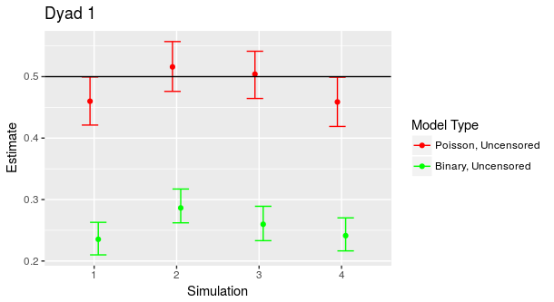

Credible Intervals for First Dyadic Parameter

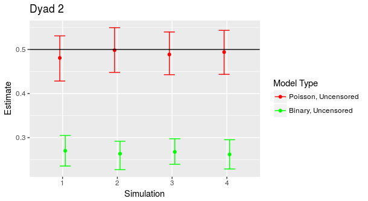

Credible Intervals for Second Dyadic Parameter

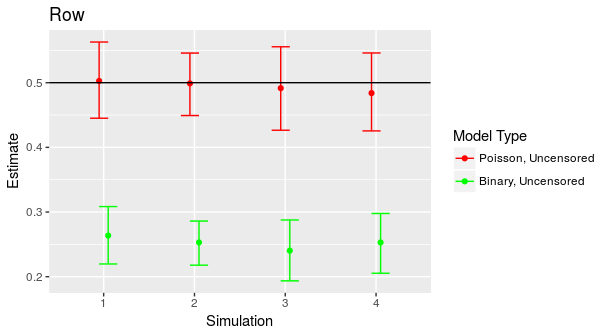

Credible Intervals for Row Parameter

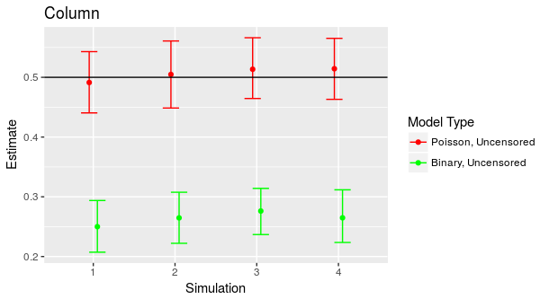

Credible Intervals for Column Parameter

We first compare the performances of the uncensored Poisson model and the uncensored “binarized” model. Figures @ref(fig:subd)-@ref(fig:subd2) compare these models for each of the given regression parameters. The black horizontal line indicates the true parameter value. Note that we don’t assess the intercept parameter for each model, as we aren’t interested in its performance and only include it for stability in the model.

Unsurprisingly, the uncensored Poisson model almost perfectly captures all the true parameters. All the credible intervals lie within the true values with little uncertainty. This makes sense intuitively. The Poisson model takes into account all features of the observed network, which itself was generated via a Poisson process. It is worth noting the first dyadic covariate, which is a standard normally-distributed variable, is estimated least accurately. In theory one would expect the row covariate to be estimated the worst, given that it is hardest to estimate due to a lack of identifiability.

The model for the “binarized” version of the network performs significantly- and consistently- worse than the Poisson model. For each of the four parameters of interest, the binary model settles around an estimate of about $\frac{1}{4}$, half that of the true of true parameter $\frac{1}{2}$. These estimates also have about the same level of uncertainty as the Poisson model. One possible explanation for this consistent underestimating of the model parameters is the nature of binarizing the network. By converting ties to ones and zeroes, the relationships between the observed data $X$ and $Y^{bin}$ appear to decrease in magnitude. That is, without larger ties that exceed a value of one, the slopes of the coefficients are perceived as smaller than they truly are.

### Censored vs. Uncensored

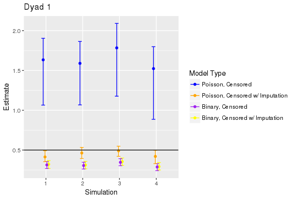

Credible Intervals for First Dyadic Parameter

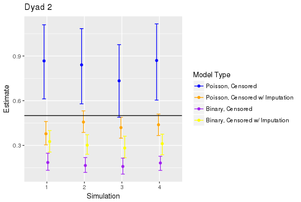

Credible Intervals for Second Dyadic Parameter

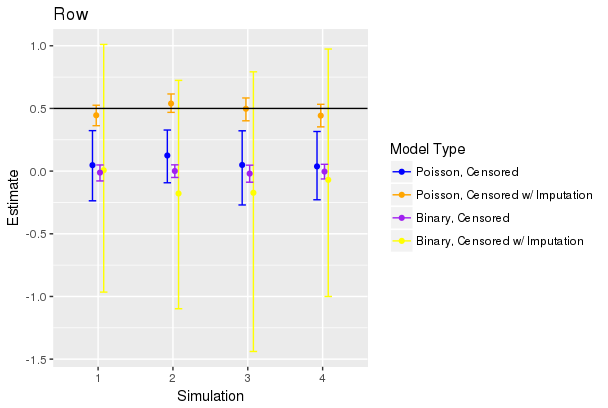

Credible Intervals for Row Parameter

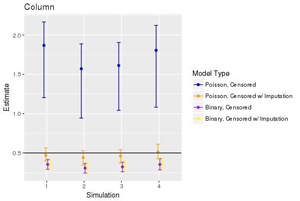

Credible Intervals for Column Parameter

We next examine how the presence of censoring affects the performance of our models. Figures @ref(fig:subd3)-@ref(fig:subd4) show the credible intervals for the Poisson and Binary models with the artificially censored matrices $S$ and $S^{bin}$. For each model we also implement likelihoods for simulating values of unobserved ties according to our methods from Section 4.

What is first notable is how poorly the censored Poisson model (without simulating values of $S$) performs in estimating the true parameters. It significantly overestimates the dyadic parameters in addition to the column covariate, and the large intervals indicate a lot of uncertainty in the estimates. The poor performance makes sense intuitively, as the censoring of most ties gives the model very little information to use for prediction. A possible explanation for the overestimation of these parameters is because the existence of only larger ties indicates that the coefficients are larger than they really are. In other words, by removing the smaller ties like 1’s and 2’s from the model, the censored matrix improperly implies that any relationships between $X$ and $S$ are larger in magnitude. It is also worth noting that the row covariate is underestimated apart from the other covariates. One reason for this is because the row effects are weakly identifiable. The Binary censored model performs poorly as well, although not as severely. Like with the uncensored network, the model consistently- and with little uncertainty- underestimates the values of the true parameters.

Conversely, the Poisson model with the newly implemented likelihood performs significantly better. Not only are the credible intervals closer to the true parameters, they are smaller as well, indicating much less uncertainty in predicting values. While the model doesn’t capture the true parameters as well as the uncensored Poisson model, it is significantly closer than the other models. This indicates that the designed likelihood method is at least partially effective at inferring potentially unobserved relationships in the network. The binary model with the addition of simulating values of $S^{bin}$ performs less well. In particular, for some parameters the model’s credible intervals are extremely large, indicating a lot of uncertainty in the estimates.

# Add Health Data

We now apply the AME models from the simulation study to data from the National Longitudinal Study of Adolescent Health, or Add Health. We choose these data because of their count nature and inherent censoring of ties.

The Add Health dataset was created as part of a multiyear study of adolescent behavior in the United States. In one part of the study, individual high schools were surveyed about friendships among students. The data contain two kinds of directed networks useful for our research; a friendship network, where students ranked their friends, and an interaction network, where students indicated how many times they interacted with their friends on a weekly basis. In addition, we have data on several actor-specific covariates, including demographic information, school year and performance, and personal habits and behaviors like smoking and drinking alcohol.

## Censored Likelihood

The censoring nature of the dataset comes from the observed friendship network. Students were asked to rank their five favorite friends of the same sex and their five favorite friends of the opposite sex. That means for a given student we can only observe at most five same-sex friendships and five opposite-sex friendships. This also means the interaction network is censored, as students were only asked about their interactions with nominated friends. The 2013 paper by Volfovsky addressed the fixed rank nature of the Add Health friendship networks, and an FRN-likelihood was designed and implemented.

Due to the count nature of its ties, we are interested in modeling the interaction network. We first model the interaction network using a Poisson model without accounting for the censoring of the network. That is, we model the network as if we have the fully observed interaction network. We then “binarize” the network like in the simulation study, and model the network using a logistic model. We then implement our likelihood for inferring potentially unobserved ties. That is, for all zero-entries in rows where five friends are nominated, we simulate from a Poisson distribution constrained from 0 to the smallest positive entry in that row.

Note that this kind of censoring likelihood implies an important assumption about the network. We are assuming that the nominated friends of a student also receive the most interaction from that student. That is, an actor interacts with his or her friends more than any other students of the same sex in the class. This assumption determines the method of simulating unobserved relationships. The assumption is not far-fetched, as we would expect students to interact with whom they deem to be friends more than whom they do not deem to be friends.

## Exploratory Analysis

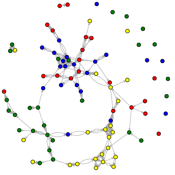

Male interaction network for chosen school. Nodes are shaded by grade level of student at time of study, where Red=9, Blue=10, Green=11, Yellow=12

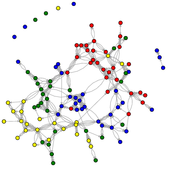

Female interaction network for chosen school. Nodes are shaded by grade level of student at time of study, where Red=9, Blue=10, Green=11, Yellow=12

We analyze the interaction networks for one of the high schools surveyed in the Add Health study. For the chosen school, we divide the network into two same-sex sub-networks. Figures @ref(fig:subd5)-@ref(fig:subd6) show plots for the male-male interaction network and the female-female interaction network, respectively. Nodes are shaded according to each student’s grade level in the school. One can see in both plots the appearance of clustering of students who belong to the same grade level. This could indicate male and female students tend to interact with students of the same grade more than with students in other grades.

One notable feature of the Add Health dataset is lack of complete nominations from students. Of the 91 males in the chosen school, only 10% of students used all five of the same-sex friendship nominations they were given, while 20% of female students used all five same-sex friendship nominations. It is possible students didn’t wish to utilize all five nominations, which would imply no one listed as a friend was truly not a friend. However, a lack of nominations could be due to a lack of responses from students. This would mean we have more missing data than what the FRN scheme implies.

## Mixed Effects Model

Our AME model contains two dyadic covariates, three sender-specific covariates, and three receiver-specific covariates:

Dyadic Covariates

1. Same grade/year of school. Students are either a freshman, sophomore, junior, or senior.
2. Same race. Students were asked whether they identified as “White”, “Black”, “Asian”, “Hispanic”, or “Other”.

Sender/Receiver Covariates

1. Self-reported student GPA.
2. Smoking Status.
3. Drinking Status.

Note that GPA, smoking status, and drinking status are included as both sender-specific and receiver-specific covariates. By doing this, we can assess how these covariates relate to both the sociability and popularity of an actor.

We run this model using four established likelihoods. First, we run the standard Poisson GLM with no regard for censoring. Second, we run the Poisson GLM with our implementation of the censorship likelihood, which infers potentially unobserved friendships. Third, we run the binary likelihood with no regard for censoring. Finally, we run the binary likelihood for censored data.

## Results

### Male Interaction Network

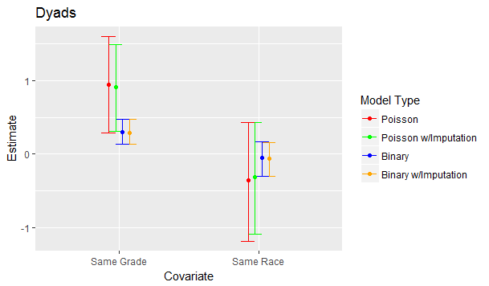

Credible Intervals for Dyadic Parameters in the Male Interaction Network

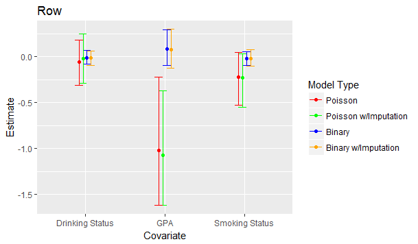

Credible Intervals for Row Parameters in the Male Interaction Network

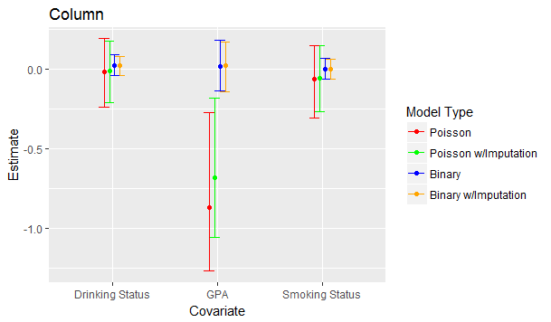

Credible Intervals for Column Parameters in the Male Interaction Network

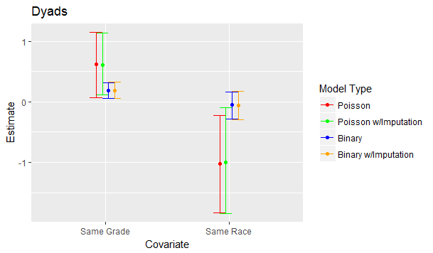

Credible Intervals for Dyadic Parameters in the Female Interaction Network

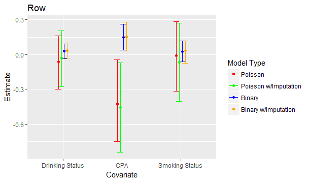

Credible Intervals for Row Parameters in the Female Interaction Network

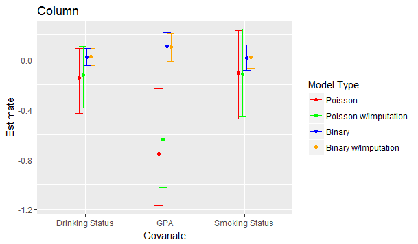

Credible Intervals for Column Parameters in the Female Interaction Network

Figures @ref(fig:subd7)-@ref(fig:subd8) show the credible intervals for the models under the male-male interaction network. Figures @ref(fig:subd9)-@ref(fig:subd10) show the credible intervals for the models under the female-female interaction network.

Another notable aspect is the closeness in estimates between the likelihood and the likelihood for censored data. Implementing the likelihood for censored data does not appear to significantly change parameter estimates. The biggest change in estimate is observed in the receiver covariate for the student’s GPA. For almost all parameters the likelihood for censored data produced slightly more narrow credible intervals.

The lack of significant change in the intervals could be because of the lack of full nominations in the network. As addressed earlier, few of the students in both the male and female network utilized all five of their friendship nominations. This meant our likelihood inferred only a small percentage of potentially censored friendships. This would lead to little change in the parameter estimates.

The covariate GPA is estimated to have a negative association as both a sender and receiver effect, indicating that students with lower GPA’s tend to interact with more students and have more students interact with them. The covariate smoking status is estimated to have a slightly negative association as a sender effect for the male network, indicating that students who smoke interact with other students less often than students who don’t smoke.

# Discussion

The results from the simulation study performed for this project showed how treating count networks as purely existence matrix significantly impedes on model accuracy. This indicates the magnitude of the relationships in the network is an important feature to capture. Models that fail to recognize counts in network ties consistently estimate parameter estimates incorrectly and fail to capture features of the network. In the context of social networks, this implies the magnitudes or frequencies of the relationships between actors provide unique information on social features. These findings indicate that when modeling any kind of count network, it is important to recognize the magnitudes of the ties. “Binarizing” the matrix such that relationships are only existent or non-existent could negatively impact model performance and incorrectly estimate network parameters.

## Future Research

It would be of interest to model more friendship networks from the Add Health dataset using the methods described in this project. The analysis of other schools could be used to show significant variation across different high schools. In addition, it would be of interest to include additional covariates to the covariates chosen in the analysis. Including other available actor features- such as participation in different curricular activities- could be included into the model as both dyadic, sender, and receiver effects.

Another area of further research is the exploration of other kinds of network censoring. While the fixed rank nomination network is a common kind of censorship, there are other methods of network censoring that could be addressed. For instance, what if network ties are constrained to some fixed value? Perhaps the amount of communication between two actors is held at some capacity. This could be the case in cellphone tower communication networks, where the amount of information transferred is constrained to some value. Another potential kind of network censoring is random censoring. How can likelihoods account for different instances of censoring, and how well can these likelihoods perform in recovering features of the true network?

# References

Hoff, P. (2005). Bilinear mixed-effects models for dyadic data. *Journal of the American Statistical Association*, 286–295.

Hoff, P. (2009). *A first course in bayesian statistical methods*. New York, NY: Springer.

Hoff, P., Fosdick, B., Volfovsky, A., & Stovel, K. (2013). Likelihoods for fixed rank nomination networks. *Network Science*, 253–277.

Warner, R., Kenny, D., & Stoto, M. (1979). A new round robin analysis of variance for social interaction data. *Journal of Personality and Social Psychology*, 1742–1757.

Wong, G. (1981). Round robin analysis of variance via maximum likelihood. *ETS Research Report Series*, i–28.